# Lab 4

Author

Erin Cagle

## Read in the Data

```r
if (!file.exists("met_all.gz"))
  download.file(
    url = "https://raw.githubusercontent.com/USCbiostats/data-science-data/master/02_met/met_all.gz",
    destfile = "met_all.gz",
    method   = "libcurl",
    timeout  = 60
    )
met <- data.table::fread("met_all.gz")
```

Download the needed file and read in the dataset.

## Prepare Data

```r
met <- met[met$temp > -17.00]
date <- as.Date(paste(met$year, met$month, met$day, sep = "-" ))
met$date = date

# below is another way to do this
# met = mutate(met, date =year, month, day, sep ="-")

weeks <- data.table::week(met$date)
met <- met[weeks < 33 & day < 8]
met_date <- met[order(met$day)]
tail(met_date)
```

```
   USAFID  WBAN year month day hour min   lat      lon elev wind.dir
1: 726813 94195 2019     8   7   18  56 43.65 -116.633  741       NA
2: 726813 94195 2019     8   7   19  56 43.65 -116.633  741       NA
3: 726813 94195 2019     8   7   20  56 43.65 -116.633  741      330
4: 726813 94195 2019     8   7   21  56 43.65 -116.633  741      320
5: 726813 94195 2019     8   7   22  56 43.65 -116.633  741      290
6: 726813 94195 2019     8   7   23  56 43.65 -116.633  741      340
   wind.dir.qc wind.type.code wind.sp wind.sp.qc ceiling.ht ceiling.ht.qc
1:           9              V     2.1          5      22000             5
2:           9              C     0.0          5      22000             5
3:           5              N     3.6          5      22000             5
4:           5              N     3.1          5      22000             5
5:           5              N     4.1          5      22000             5
6:           5              N     2.6          5      22000             5
   ceiling.ht.method sky.cond vis.dist vis.dist.qc vis.var vis.var.qc temp
1:                 9        N    16093           5       N          5 31.1
2:                 9        N    16093           5       N          5 32.2
3:                 9        N    16093           5       N          5 35.6
4:                 9        N    16093           5       N          5 35.6
5:                 9        N    16093           5       N          5 32.2
6:                 9        N    16093           5       N          5 34.4
   temp.qc dew.point dew.point.qc atm.press atm.press.qc       rh       date
1:       5      13.3            5    1011.4            5 33.69064 2019-08-07
2:       5      11.7            5    1011.4            5 28.44852 2019-08-07
3:       5      10.6            5    1010.3            5 21.76098 2019-08-07
4:       5      10.6            5    1010.1            5 21.76098 2019-08-07
5:       5       9.4            5    1010.1            5 24.38326 2019-08-07
6:       5      11.1            5    1009.0            5 24.09216 2019-08-07
```

```r
met_avg <- met_date[,.(
  temp     = mean(temp,na.rm=TRUE),
  rh       = mean(rh,na.rm=TRUE),
  wind.sp  = mean(wind.sp,na.rm=TRUE),
  vis.dist = mean(vis.dist,na.rm=TRUE),
  lat      = mean(lat),
  lon      = mean(lon),
  elev     = mean(elev,na.rm=TRUE),
  dew.point = mean(dew.point,na.rm=TRUE)
), by=c("USAFID")]
```

Find the averages based on the stations

```r
cen_lat <- 39.71
cen_lon <- -98.00

region <- ifelse(met_avg$lat > cen_lat & met_avg$lon < cen_lon, "NW",
                  ifelse(met_avg$lat > cen_lat & met_avg$lon > cen_lon, "NE",
                  ifelse(met_avg$lat < cen_lat & met_avg$lon < cen_lon, "SW",
                  ifelse(met_avg$lat < cen_lat & met_avg$lon > cen_lon, "SE", "At Center"))))
met_avg$region <- region

met_avg$elevcat <- ifelse(met_avg$elev > 252, "High", "Low")
```

Identify central lines of lat and long. Define regions based on these lines. Define categories for elevation.

## Using geom_violin

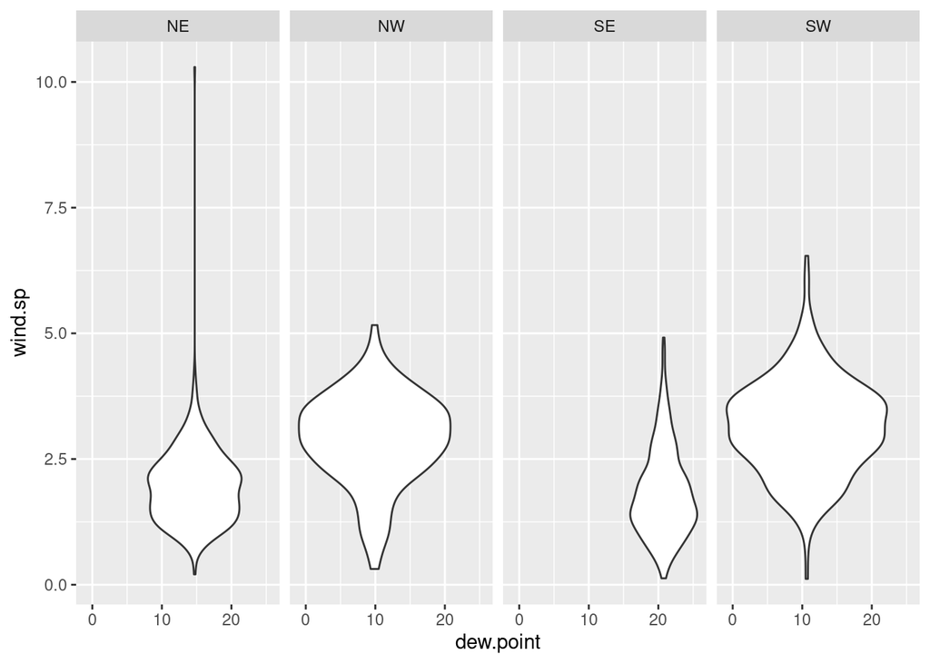

```r
library(ggplot2)
ggplot(met_avg[!is.na(wind.sp) & !is.na(dew.point)]) +
  geom_violin(mapping = aes(x = dew.point, y = wind.sp)) +
  facet_wrap(~ region, nrow = 1)
```

NW and SW regions appear to have similar densities while NE and SE have a similar shape on the lower end of wind speed.

## Using geom_jitter and stat_smooth

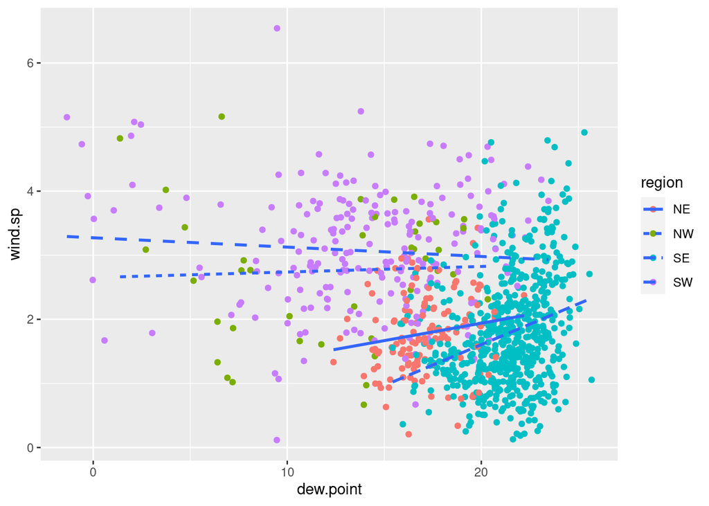

```r
met_avg <- met_avg[!is.na(wind.sp) & !is.na(dew.point)]
ggplot(met_avg[1:1000],mapping = aes(x = dew.point, y = wind.sp)) +
  geom_point(mapping = aes (color = region), position = "jitter") +
  geom_smooth(mapping =aes (linetype = region), method = lm, se = FALSE)
```

## Using geom_bar

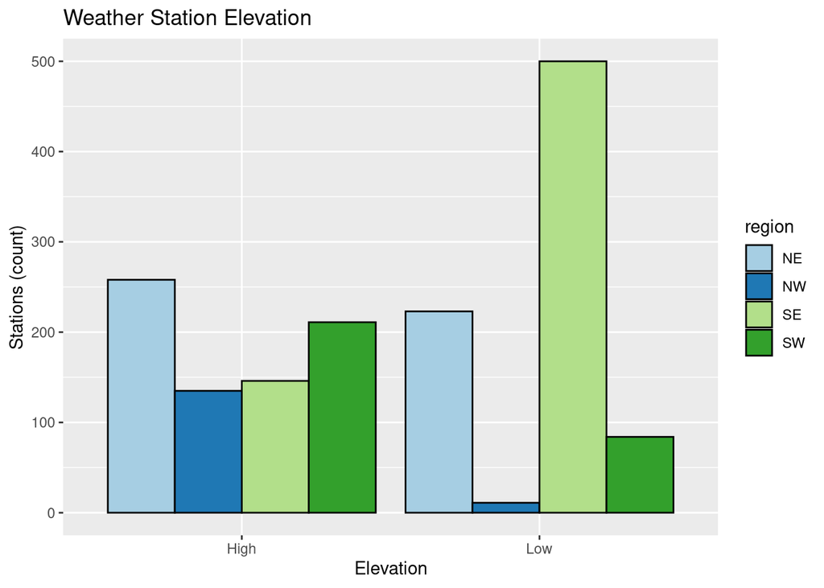

```r
ggplot(data = met_avg) +
  geom_bar(mapping = aes(x = elevcat, fill = region), color = "black", position = "dodge") +
    scale_fill_brewer(palette = "Paired") +
  labs(title = "Weather Station Elevation") +
  labs(x = "Elevation", y = "Stations (count)")
```

Stations at higher elevations appear to be more evenly spread throughout the regions. Conversely, there appears to be a significant disparity between the number of stations at lower elevations between regions. SE has the most, and NW has the least.

## Using stat_summary

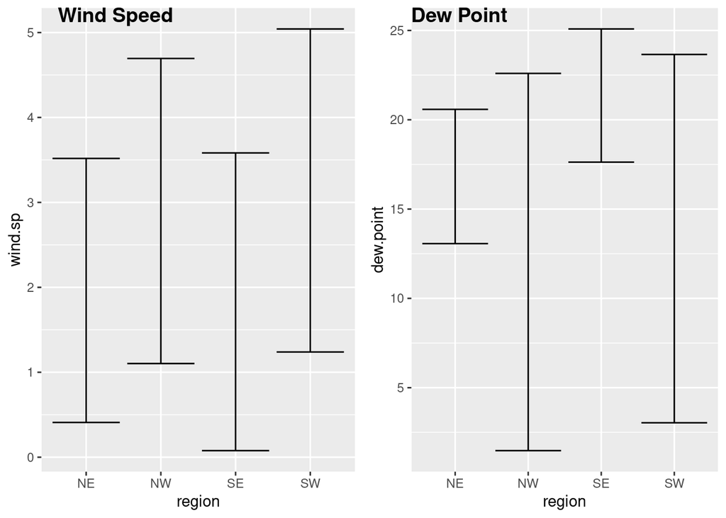

```r
library(Hmisc)
library(cowplot)
wind <- ggplot(data = met_avg) + stat_summary(mapping = aes(x = region, y = wind.sp), fun.data="mean_sdl", geom = "errorbar")
dew <- ggplot(data = met_avg) + stat_summary(mapping = aes(x = region, y = dew.point), fun.data="mean_sdl", geom = "errorbar")
plot_grid(wind, dew, labels = c("Wind Speed", "Dew Point"))
```

Wind speed appears to have equal error in each region. However, dew point for NW and SW regions have large error ranges while NE and SE have relatively small error bars.

## Mapping

```r
met2 <- met[!is.na(rh)]
library(leaflet)
met_avg2 <- met[,.(rh = mean(rh,na.rm=TRUE), lat = mean(lat), lon = mean(lon)),  by=c("USAFID")]
temp.pal <- colorNumeric(c('lightblue','blue','navy'), domain=met_avg2$rh)
leaflet(met_avg2) |>
  addProviderTiles('CartoDB.Positron') |>
  addCircles(lat = ~lat, lng= ~lon, label = ~paste0(round(rh)), color = ~temp.pal(rh), opacity = 1, fillOpacity = 1, radius = 500) |> addLegend('bottomleft', pal=temp.pal, values=met_avg2$rh, title='Relative Humidity', opacity=1)
```

[interactive chart not shown]

Humidity increases from west to east coast

## Using ggplot extension

[figure not shown]

```r
region <- ifelse(met_date$lat > cen_lat & met_date$lon < cen_lon, "NW",
                  ifelse(met_date$lat > cen_lat & met_date$lon > cen_lon, "NE",
                  ifelse(met_date$lat < cen_lat & met_date$lon < cen_lon, "SW",
                  ifelse(met_date$lat < cen_lat & met_date$lon > cen_lon, "SE", "At Center"))))
met_date$region <- region
met_dayavg <- met_date[,.(
  temp     = mean(temp,na.rm=TRUE),
  rh       = mean(rh,na.rm=TRUE),
  wind.sp  = mean(wind.sp,na.rm=TRUE),
  vis.dist = mean(vis.dist,na.rm=TRUE),
  lat      = mean(lat),
  lon      = mean(lon),
  elev     = mean(elev,na.rm=TRUE),
  dew.point = mean(dew.point,na.rm=TRUE)
), by=c("day")]
library(gifski)
library(gganimate)
ggplot(met_dayavg, aes(x = temp, y = rh)) +
  labs(title = 'Weather By Day', x = "Temperature", y = "Relative Humidity") +
  transition_states(day, transition_length = 2, state_length = 1) +
  enter_fade() +
  exit_shrink() +
  ease_aes('sine-in-out')
```